# Assignment 9

Kyle Walker

11/11/2019

### Decision Tree on the Titanic data

#### 1. This following codes build a predictive model to predict if a passenger in the titanic is survived or not. A common practice is to split the data into 2 subdata: a train data and a test data. The model is build from the train data and then tested on the test data.

```r
library(caret)
library(dplyr)
library(tidyverse)
library(readr)
library(e1071)
library(rattle)
library(rpart)
titanic <- read_csv(file = "C:/Users/student/Documents/Senior Year/MATH 421/titanic.csv")
```

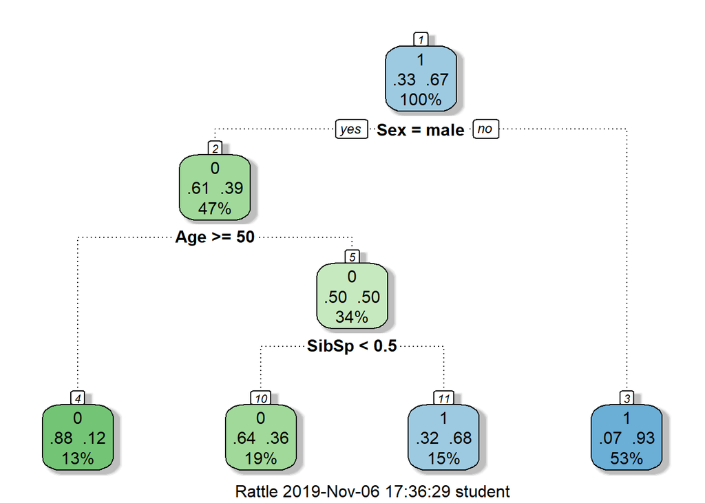

```r
titanic <- na.omit(titanic)
titanic <- titanic %>%
  select(-PassengerId, -Name, -Ticket, -Cabin)
titanic$Survived <- as.factor(titanic$Survived)
# Split the data into 70% training and 30% testing
splitIndex <- createDataPartition(titanic$Survived, p = .70, list = FALSE)
train <- titanic[splitIndex,]
test <- titanic[-splitIndex,]

# build a tree
mytree <- rpart(Survived ~ ., data = train, method = "class")

# Plot the tree
fancyRpartPlot(mytree)
```

```r
# Evaluate the tree on the testing data

#predict on testing data
pred <- predict(mytree,test, type = "class")

#Evaluate the predictions
cm=confusionMatrix(data = pred, reference = test$Survived, positive = "1")
cm
```

```
## Confusion Matrix and Statistics
##
##           Reference
## Prediction  0  1
##          0 12 13
##          1  6 23
##
##                Accuracy : 0.6481
##                  95% CI : (0.5062, 0.7732)
##     No Information Rate : 0.6667
##     P-Value [Acc > NIR] : 0.6720
##
##                   Kappa : 0.2785
##
##  Mcnemar's Test P-Value : 0.1687
##
##             Sensitivity : 0.6389
##             Specificity : 0.6667
##          Pos Pred Value : 0.7931
##          Neg Pred Value : 0.4800
##              Prevalence : 0.6667
##          Detection Rate : 0.4259
##    Detection Prevalence : 0.5370
##       Balanced Accuracy : 0.6528
##
##        'Positive' Class : 1
##
```

### Following the codes and

#### - Compute the training error of a decision tree with maxdepth=1

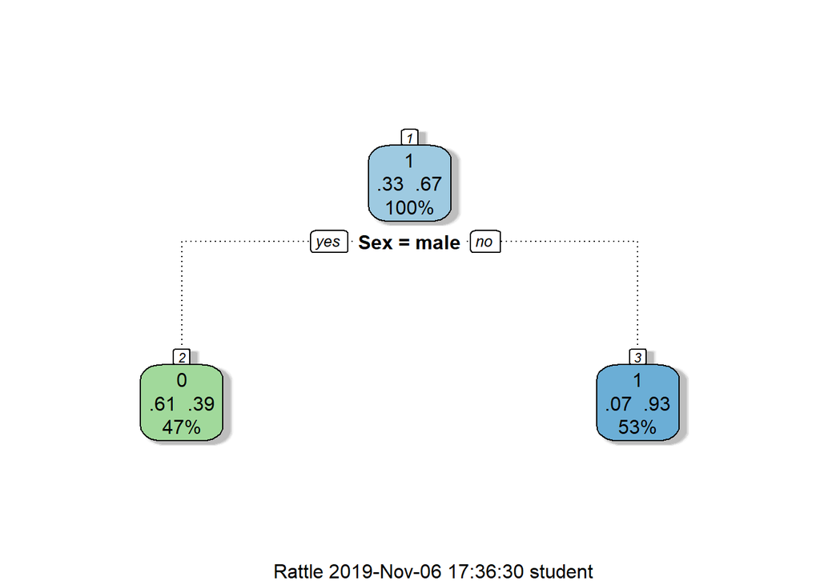

```r
# Build another tree
# Tree with depth=1
library(rpart)
mytree2 <- rpart(Survived ~ ., data = train, method = "class", control = rpart.control(maxdepth = 1))
fancyRpartPlot(mytree2)
```

```r
pred <- predict(mytree2, train, type="class")

cm = confusionMatrix(data = pred, reference = train$Survived, positive = "1")
1 - cm$overall[[1]]
```

```
## [1] 0.2248062
```

#### - Compute the training errors of decision trees with `maxdepth` running from 1 to 10. How does the training error change when the `maxdepth` increases.

```r
for(i in 1:10) {
  mytree2 <- rpart(Survived ~ ., data = train, method = "class", control = rpart.control(maxdepth = i))
  pred <- predict(mytree2, train, type="class")

  cm = confusionMatrix(data = pred, reference = train$Survived, positive = "1")
  print(1 - cm$overall[[1]])
}
```

```
## [1] 0.2248062
## [1] 0.2248062
## [1] 0.1705426
## [1] 0.1705426
## [1] 0.1705426
## [1] 0.1705426
## [1] 0.1705426
## [1] 0.1705426
## [1] 0.1705426
## [1] 0.1705426
```

```r
# The training error decreases as the max depth increases
```

#### - Compute the test errors of decision trees with `maxdepth` running from 1 to 10. How does the test error change when the `maxdepth` increases.

```r
for(i in 1:10) {
  mytree2 <- rpart(Survived ~ ., data = train, method = "class", control = rpart.control(maxdepth = i))
  pred <- predict(mytree2, test, type="class")

  cm = confusionMatrix(data = pred, reference = test$Survived, positive = "1")
  print(1 - cm$overall[[1]])
}
```

```
## [1] 0.3333333
## [1] 0.3333333
## [1] 0.3518519
## [1] 0.3518519
## [1] 0.3518519
## [1] 0.3518519
## [1] 0.3518519
## [1] 0.3518519
## [1] 0.3518519
## [1] 0.3518519
```

```r
#As the max depth increases on the testing data, the training error increases
```

#### - Parameter tuning is the process to find out the best selection for the parameter. What would be the best selection of the parameter `maxdepth`?

```r
# The best max depth for this data set would be 1, this achieves the lowest validation error
```